# Identify max rank for AUCell

Ally Hawkins

2025-02-03

This notebook is used to find the appropriate `aucMaxRank` to use with `AUCell` for all samples in `SCPCP00015`.

From the [`AUCell` vignette](https://bioconductor.org/packages/release/bioc/vignettes/AUCell/inst/doc/AUCell.html):

> It is important to check that most cells have at least the number of expressed/detected genes that are going to be used to calculate the AUC (`aucMaxRank` in `calcAUC`()). The histogram provided by `AUCell_buildRankings`() allows to quickly check this distribution.

Here we will look at a histogram showing the number of genes detected per cell for each sample and use that information to pick a threshold (percentage of genes) to use across all samples.

## Setup

```r
suppressPackageStartupMessages({
  # load required packages
  library(SingleCellExperiment)
  library(ggplot2)
})

# Set default ggplot theme
theme_set(
  theme_classic()
)
```

```r
# The base path for the OpenScPCA repository, found by its (hidden) .git directory
repository_base <- rprojroot::find_root(rprojroot::is_git_root)

# The current data directory, found within the repository base directory
data_dir <- file.path(repository_base, "data", "current", "SCPCP000015")

# paths to all processed sce files
sce_files <- list.files(data_dir, pattern = "*processed.rds", full.names = TRUE, recursive = TRUE)
```

```r
# read in SCE files
sce_list <- sce_files |>
  purrr::map(readr::read_rds)
```

## Filter `SingleCellExperiment` objects

The default `aucMaxRank` is calculated as `ceiling(0.05*nrow(exprMat))` where the `exprMat` is the counts matrix. For the processed `SingleCellExperiment` objects in ScPCA we include all genes in the index, regardless of if they are detected in our sample. This means the rankings might include a bunch of genes that aren’t actually present and the `aucMaxRank` would be calculated based on a set of genes that aren’t even there, setting the threshold higher than it should be. Because of this, we probably want to filter the `SingleCellExperiment` objects to remove any genes that are not detected in any cells prior to calculating ranks or running `AUCell`.

```r
# get a list of filtered sce
# remove any genes that are not detected in any cells
sce_list <- sce_list |>
  purrr::map(\(sce){

    genes_to_remove <- rowData(sce)$detected > 0
    filtered_sce <- sce[genes_to_remove , ]

  })
```

## Number of genes detected

Below we will look at the distribution of the number of genes detected per cell for each sample.

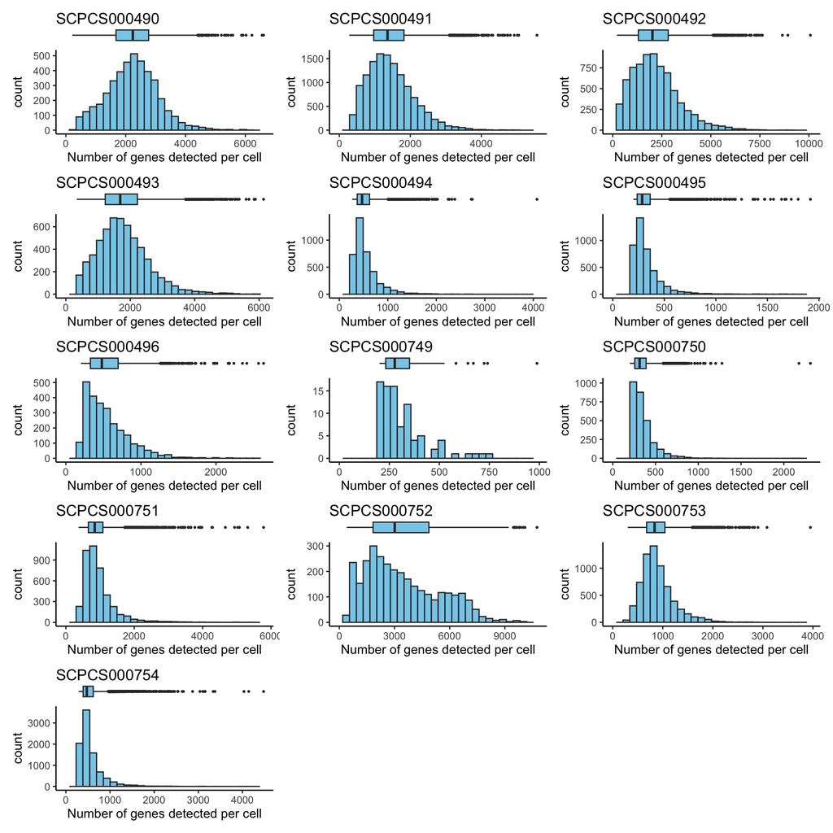

```r
# make a list of the `countByCell` as AUCell does
names(sce_list) <- stringr::str_extract(sce_files, "SCPCS\\d+")
count_df_list <- sce_list |>
  purrr::map(counts) |>
  purrr::map(
    \(counts) {
      countByCell <- Matrix::colSums(counts > 0, na.rm = TRUE)
      data.frame(count_by_cell = countByCell)
    })

# first, make the plots
count_df_list |>
  purrr::imap(
    \(count_df, sample_id) {
        count_hist <- ggplot(count_df) +
          aes(x = count_by_cell) +
          geom_histogram(color = "grey20", fill = "skyblue", bins = 30) +
          xlim(0, max(count_df$count_by_cell)) +
          xlab("Number of genes detected per cell")

        count_box <- ggplot(count_df) +
          aes(x = count_by_cell, y = "") +
          geom_boxplot(color = "grey20", fill = "skyblue", outlier.size = 0.5) +
          theme_void() +
          xlim(0, max(count_df$count_by_cell)) +
          ggtitle(sample_id)

      count_box / count_hist + patchwork::plot_layout(heights = c(0.2, 1))
    }
  ) |>
  patchwork::wrap_plots(nrow = 5)
```

```r
# second, print a table of the stats
count_df_list |>
  purrr::map(
     \(count_df) {
         c(
          min=min(count_df$count_by_cell),
          quantile(count_df$count_by_cell, c(.01,.05, .10, .50, 1))
        )
     }) |>
  dplyr::bind_rows(.id = "sample_id")
```

```
## # A tibble: 13 × 7
##    sample_id     min  `1%`  `5%` `10%` `50%` `100%`
##    <chr>       <dbl> <dbl> <dbl> <dbl> <dbl>  <dbl>
##  1 SCPCS000490   213  466.  796. 1102.  2238   6608
##  2 SCPCS000491   282  426.  552.  676   1358   5567
##  3 SCPCS000492   215  408   556   771   2024  10079
##  4 SCPCS000493   338  443.  622.  820.  1687   6137
##  5 SCPCS000494   264  287   306   323    469   4077
##  6 SCPCS000495   200  201   206   214    285   1917
##  7 SCPCS000496   200  208   232   254    479   2633
##  8 SCPCS000749   201  202.  205.  212.   277    988
##  9 SCPCS000750   200  202   211   224    314   2311
## 10 SCPCS000751   373  440   489   539    844   5782
## 11 SCPCS000752   402  571.  766. 1076   3011  10748
## 12 SCPCS000753   299  352.  470   549    836   3950
## 13 SCPCS000754   290  319   337   351    474   4478
```

Now we will look at the potential thresholds for `aucMaxRank` using 5% and 1% of genes. The numbers printed here represent the total number of genes that would be used as the `aucMaxRank` for a given dataset using the threshold. We can then use the histograms to see how many cells have at least that number of genes detected. Remember, we want to pick a number of genes that are detected in most cells. If we picked a max rank higher than the number of genes detected in most cells, the non-detected genes that are randomly ordered would play an outsized role in our AUC values.

### 5%

```r
# get max rank using 1% threshold
threshold_list <- sce_list |>
  purrr::map_dbl(\(sce){ceiling(nrow(counts(sce))*0.05)})

# make it legible
data.frame(
  max_rank = threshold_list
)
```

```
##             max_rank
## SCPCS000490     1746
## SCPCS000491     1705
## SCPCS000492     1776
## SCPCS000493     1631
## SCPCS000494     1385
## SCPCS000495     1174
## SCPCS000496     1219
## SCPCS000749      624
## SCPCS000750     1197
## SCPCS000751     1448
## SCPCS000752     1696
## SCPCS000753     1532
## SCPCS000754     1502
```

This looks too high based on our histograms. We would have a lot of cells where the number of genes detected is lower than the max rank, which is not ideal.

### 1%

```r
# get max rank using 1% threshold
threshold_list <- sce_list |>
  purrr::map_dbl(\(sce){ceiling(nrow(counts(sce))*0.01)})

# make it legible
data.frame(
  max_rank = threshold_list
)
```

```
##             max_rank
## SCPCS000490      350
## SCPCS000491      341
## SCPCS000492      356
## SCPCS000493      327
## SCPCS000494      277
## SCPCS000495      235
## SCPCS000496      244
## SCPCS000749      125
## SCPCS000750      240
## SCPCS000751      290
## SCPCS000752      340
## SCPCS000753      307
## SCPCS000754      301
```

This looks better to me. I also think there’s enough variation in some of the samples that we don’t want to just pick one max rank for all samples, but instead use a percentage of the total genes detected.

## Conclusions

- Prior to running `AUCell` we should remove any genes that are not detected in any cells.
- Using a cutoff of 1% of the total genes detected seems like a reasonable choice for the `aucMaxRank`. This allows us to account for the variation in genes detected per sample, but we should be sure to be careful when interpreting results as using different cutoffs for each sample could impact the AUC values.